# Assignment 2

Zygmut

28-11-23

## Introduction

This assignment explores the Prestige data frame from the “car” package, aiming to analyze the relationship between variables, particularly focusing on the regression model with “income” as the dependent variable.

## Pacakages

```r
library(car) # Data
```

```r
library(ggplot2) # Data plotting
library(dplyr) # Data manipulation
library(patchwork) # Plot layout
library(purrr) # Functional programming
library(corrplot) # Correlation plot
library(RColorBrewer) # Nice color palette
```

## Load dataset

```r
df <- Prestige
```

## 01

```r
summary(df)
```

```
##    education          income          women           prestige
##  Min.   : 6.380   Min.   :  611   Min.   : 0.000   Min.   :14.80
##  1st Qu.: 8.445   1st Qu.: 4106   1st Qu.: 3.592   1st Qu.:35.23
##  Median :10.540   Median : 5930   Median :13.600   Median :43.60
##  Mean   :10.738   Mean   : 6798   Mean   :28.979   Mean   :46.83
##  3rd Qu.:12.648   3rd Qu.: 8187   3rd Qu.:52.203   3rd Qu.:59.27
##  Max.   :15.970   Max.   :25879   Max.   :97.510   Max.   :87.20
##      census       type
##  Min.   :1113   bc  :44
##  1st Qu.:3120   prof:31
##  Median :5135   wc  :23
##  Mean   :5402   NA's: 4
##  3rd Qu.:8312
##  Max.   :9517
```

```r
str(df)
```

```
## 'data.frame':    102 obs. of  6 variables:
##  $ education: num  13.1 12.3 12.8 11.4 14.6 ...
##  $ income   : int  12351 25879 9271 8865 8403 11030 8258 14163 11377 11023 ...
##  $ women    : num  11.16 4.02 15.7 9.11 11.68 ...
##  $ prestige : num  68.8 69.1 63.4 56.8 73.5 77.6 72.6 78.1 73.1 68.8 ...
##  $ census   : int  1113 1130 1171 1175 2111 2113 2133 2141 2143 2153 ...
##  $ type     : Factor w/ 3 levels "bc","prof","wc": 2 2 2 2 2 2 2 2 2 2 ...
```

The data holds `102` observations and `6` varaibles with the following types:

- education: `num`
- income: `int`
- women: `num`
- prestige: `num`
- census: `int`
- type: `Factor` with classes [bc, prof, wc]

Overall, the data makes sense for their respective categories; not having negative values nor extreme values; Though, `type` has 4 unexpected `NaN` values. Exploring the data could give us some insights on what values to asign to this missing types.

```r
(nan_values <- df[is.na(df$type), ])
```

```
##             education income women prestige census type
## athletes        11.44   8206  8.13     54.1   3373 <NA>
## newsboys         9.62    918  7.00     14.8   5143 <NA>
## babysitters      9.46    611 96.53     25.9   6147 <NA>
## farmers          6.84   3643  3.60     44.1   7112 <NA>
```

```r
(nan_names <- row.names(nan_values))
```

```
## [1] "athletes"    "newsboys"    "babysitters" "farmers"
```

Assuming that the labels are correct, we can assign manually each of the types:

- **Athletes**: prof
- **Newsboys**: bc
- **Babysitters**: prof
- **Farmers**: bc

There’s also the possibility to assign them by analyzing the relation between all of the other variables with our dependant varaible (income) but, for this exercise, I’ll be using data interpretation and contextual analysis to fill in the values. I’ll be using [deplyr](https://dplyr.tidyverse.org/) to mutate the data, as seen [here](https://dplyr.tidyverse.org/reference/mutate.html).

```r
df <- df %>%
  mutate(
    type = case_when(
      row.names(df) %in% c("athletes", "babysitters") ~ "prof",
      row.names(df) %in% c("newsboys", "farmers") ~ "bc",
      TRUE ~ type
    )
  )

df[nan_names, ]
```

```
##             education income women prestige census type
## athletes        11.44   8206  8.13     54.1   3373 prof
## newsboys         9.62    918  7.00     14.8   5143   bc
## babysitters      9.46    611 96.53     25.9   6147 prof
## farmers          6.84   3643  3.60     44.1   7112   bc
```

## 02

The use of ggpairs or pairs could prove useful to show the relation of the whole dataframe. As to only showing the explicit data that we want to study, a more fine-grained method will be implemented.

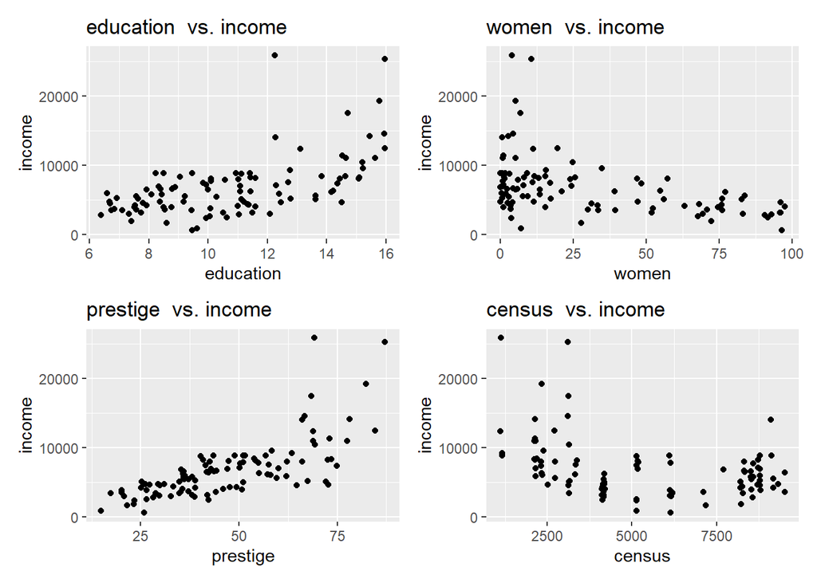

```r
names_not_income <- setdiff(names(df), c("income", "type"))

plots <- lapply(names_not_income, function(variable) {
  ggplot(df, aes(x = .data[[variable]], y = income)) +
    geom_point() +
    labs(
      title = paste(variable, " vs. income"),
      x = variable,
      y = "income"
    )
})

# This uses the purrr package that allows us to combine all of the plots
reduce(plots, `+`)
```

We left out `type` to use a more interesting plot, such as a boxplot. We’re doing this as the `type` data is a *factor* and using a scatterplot wont give us a plot that is difficult to understand

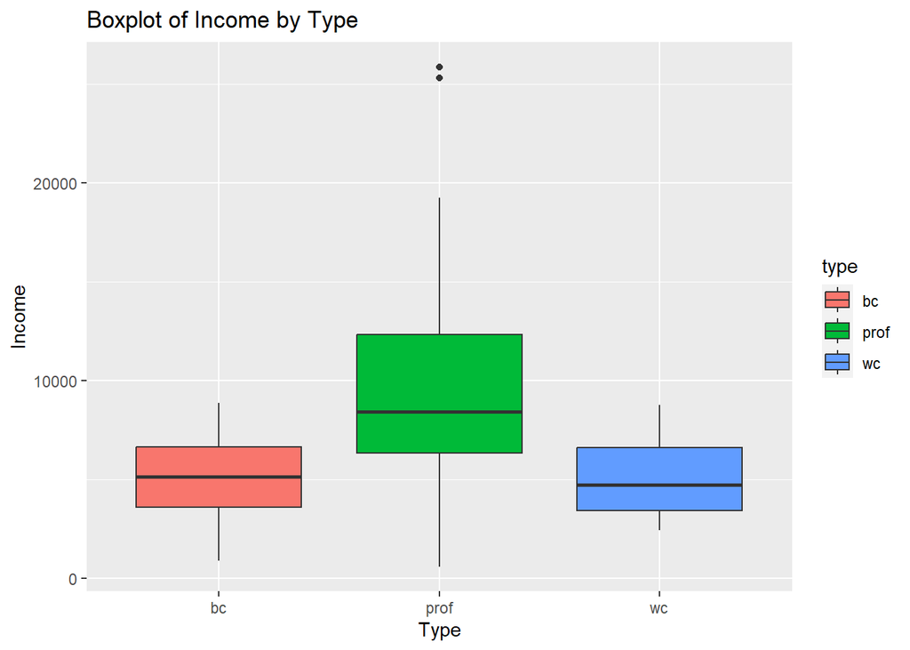

```r
ggplot(df, aes(x = type, y = income, fill = type)) +
  geom_boxplot() +
  labs(
    title = "Boxplot of Income by Type",
    x = "Type",
    y = "Income"
  )
```

A correlation graph could prove useful as to quicly examine what variables could ave priority when applying linear regressions.

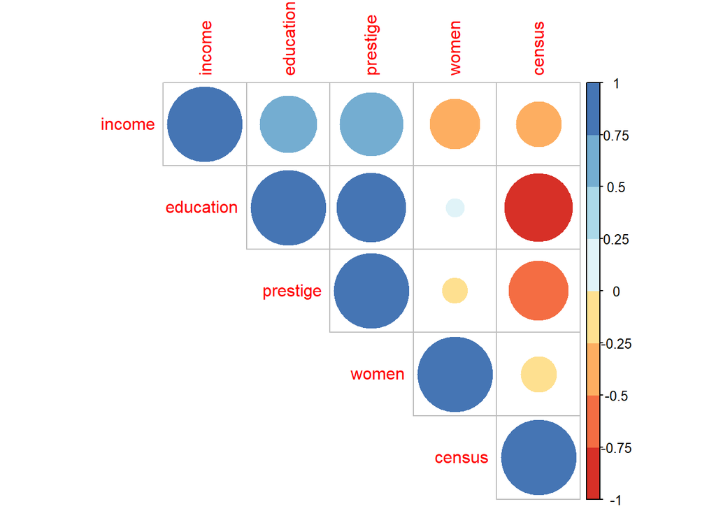

```r
corrplot(cor(df %>% select(-type)),
  type = "upper",
  order = "hclust",
  col = brewer.pal(n = 8, name = "RdYlBu")
)
```

## 03

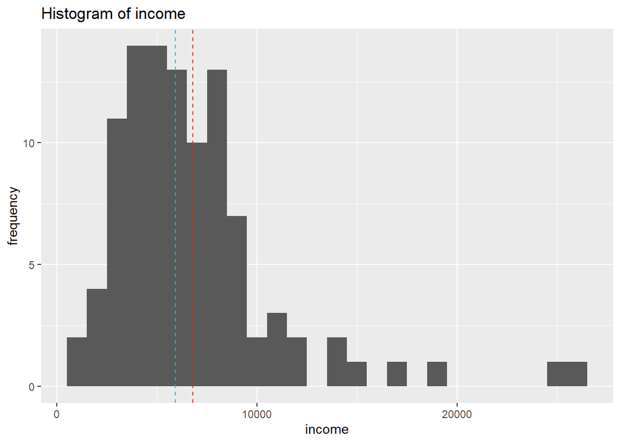

```r
ggplot(df, aes(x = income)) +
  geom_histogram(binwidth = 1000) +
  geom_vline(
    xintercept = median(df$income),
    color = "#10b7f4",
    linetype = "dashed"
  ) +
  geom_vline(
    xintercept = mean(df$income),
    color = "#c03a09",
    linetype = "dashed"
  ) +
  labs(
    title = "Histogram of income",
    x = "income",
    y = "frequency"
  )
```

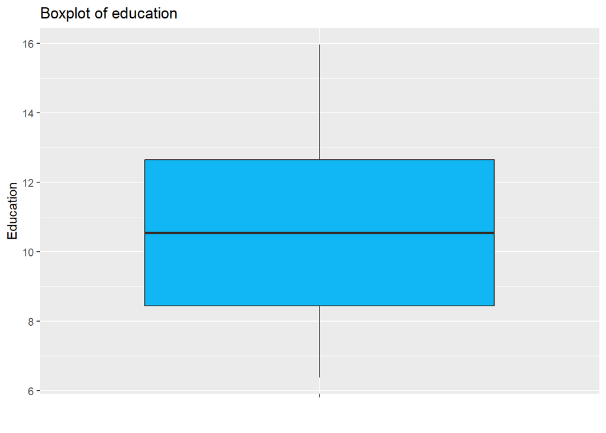

```r
ggplot(df, aes(x = "", y = education)) +
  geom_boxplot(fill = "#10b7f4") +
  labs(
    title = "Boxplot of education",
    x = "",
    y = "Education"
  )
```

The boxplot shows a relatively normal distribution of the education from 8.5 to 12.5 aproximatelly, presenting some whiskers to the min and max values being 6.380 and 15.970 respectivelly.

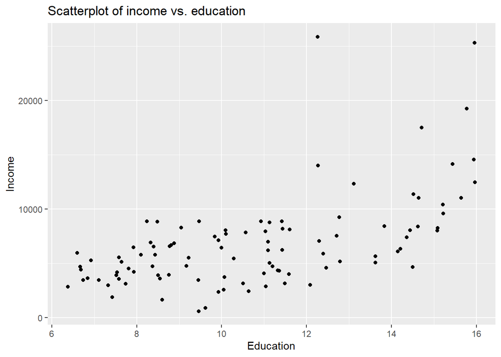

```r
ggplot(df, aes(x = education, y = income)) +
  geom_point() +
  labs(
    title = "Scatterplot of income vs. education",
    x = "Education",
    y = "Income"
  )
```

```r
set.seed(27)
linear_model <- lm(income ~ education, data = df)
r_squared_linear <- summary(linear_model)$r.squared
summary(linear_model)
```

```
##
## Call:
## lm(formula = income ~ education, data = df)
##
## Residuals:
##     Min      1Q  Median      3Q     Max
## -5493.2 -2433.8   -41.9  1491.5 17713.1
##
## Coefficients:
##             Estimate Std. Error t value Pr(>|t|)
## (Intercept)  -2853.6     1407.0  -2.028   0.0452 *
## education      898.8      127.0   7.075 2.08e-10 ***
## ---
## Signif. codes:  0 '***' 0.001 '**' 0.01 '*' 0.05 '.' 0.1 ' ' 1
##
## Residual standard error: 3483 on 100 degrees of freedom
## Multiple R-squared:  0.3336, Adjusted R-squared:  0.3269
## F-statistic: 50.06 on 1 and 100 DF,  p-value: 2.079e-10
```

The coefficient for education (898.8) suggests that, on average, for each one-unit increase in education, the income is expected to increase by 898.8 units.

The p-value returned by the model (2.079e-10) is exceptionally good as its very close to zero, though the model expresses a very low R-squared value (0.3336), meaning that it only explains 33% of the variance in the data.

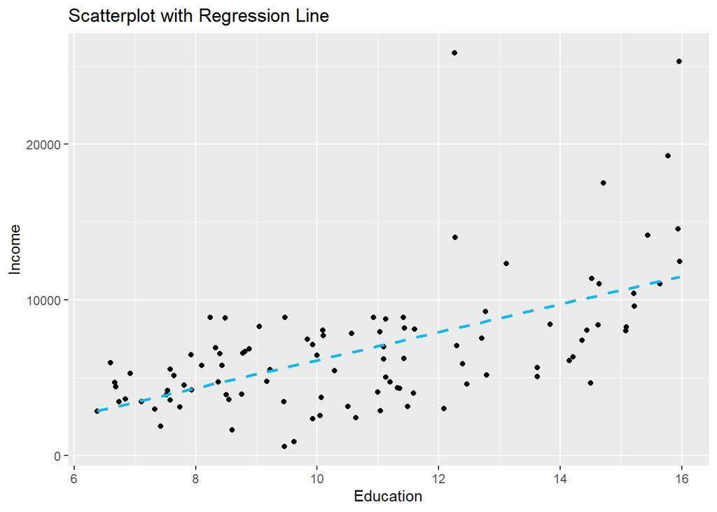

```r
ggplot(df, aes(x = education, y = income)) +
  geom_point() +
  geom_smooth(
    method = "lm",
    formula = y ~ x,
    se = FALSE,
    color = "#10b7f4",
    linetype = "dashed"
  ) +
  labs(
    title = "Scatterplot with Regression Line",
    x = "Education",
    y = "Income"
  )
```

Visually, the model seems to not be fitting the observations as well as I wanted, as it doesn’t follow the pattern of the whole plot. Altough only being a visual clue this can, in fact, mean that the best model is non-linear

## 04

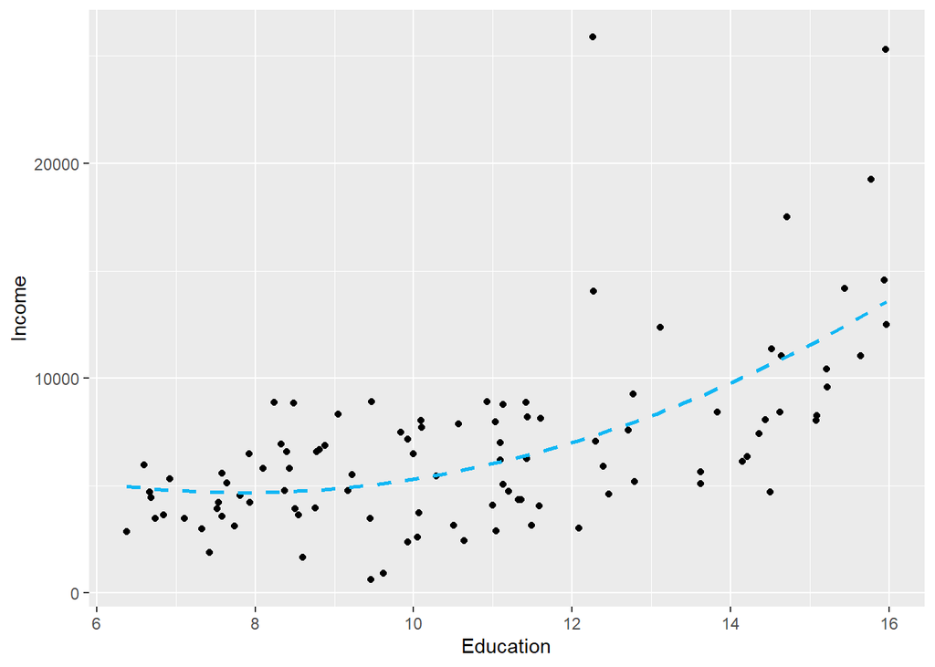

```r
poly_model <- lm(income ~ poly(education, 2), data = df)
r_squared_poly <- summary(poly_model)$r.squared

ggplot(
  df,
  aes(x = education, y = income)
) +
  geom_point() +
  geom_smooth(
    method = "lm",
    formula = y ~ poly(x, 2),
    se = FALSE,
    color = "#10b7f4",
    linetype = "dashed"
  ) +
  labs(x = "Education", y = "Income")
```

```r
summary(poly_model)
```

```
##
## Call:
## lm(formula = income ~ poly(education, 2), data = df)
##
## Residuals:
##     Min      1Q  Median      3Q     Max
## -5951.4 -2091.1  -358.2  1762.4 18574.2
##
## Coefficients:
##                     Estimate Std. Error t value Pr(>|t|)
## (Intercept)           6797.9      333.5  20.381  < 2e-16 ***
## poly(education, 2)1  24645.9     3368.5   7.316 6.77e-11 ***
## poly(education, 2)2   9488.3     3368.5   2.817  0.00586 **
## ---
## Signif. codes:  0 '***' 0.001 '**' 0.01 '*' 0.05 '.' 0.1 ' ' 1
##
## Residual standard error: 3369 on 99 degrees of freedom
## Multiple R-squared:  0.383,  Adjusted R-squared:  0.3706
## F-statistic: 30.73 on 2 and 99 DF,  p-value: 4.146e-11
```

The p-value of the polinomial model is far closer to zero than the linear, suggesting that this model is better than the linear. This lower p-value suggests that the additional polynomial terms (in this case education^2) contribute significantly explanation of “income”

Comparing the R^2 value we can conclude that:

```r
better_model <- ifelse(
  r_squared_poly > r_squared_linear,
  "polynomial",
  "linear"
)

cat("The", better_model, "model is better\n")
```

```
## The polynomial model is better
```

## 05

Using purrr, we can apply functions over two inputs (education & income) as shown [here](https://purrr.tidyverse.org/reference/map2.html). Due to the `exp` function returning `Inf`, a sanity check is introduced using the `ifelse` conditional having for fallback the original values.

```r
methods <- c(
  identity,
  log,
  sqrt,
  exp,
  function(x) x^2,
  function(x) x^3,
  function(x) x^4
)

transformed_data <- map2(
  methods, methods,
  ~ data.frame(
    income = ifelse(
      is.finite(.x(df$income)), .x(df$income), df$income
    ),
    education = ifelse(
      is.finite(.y(df$education)), .y(df$education), df$education
    )
  )
)
```

```r
models <- map(transformed_data, function(data) {
  model <- lm(income ~ education, data = data)
  return(list(
    income = data$income,
    education = data$education,
    model = model,
    r_squared = summary(model)$r.squared
  ))
})
```

For academic purposes, a sample of the models previously generated can be feteched and ploted with their respective linear models.

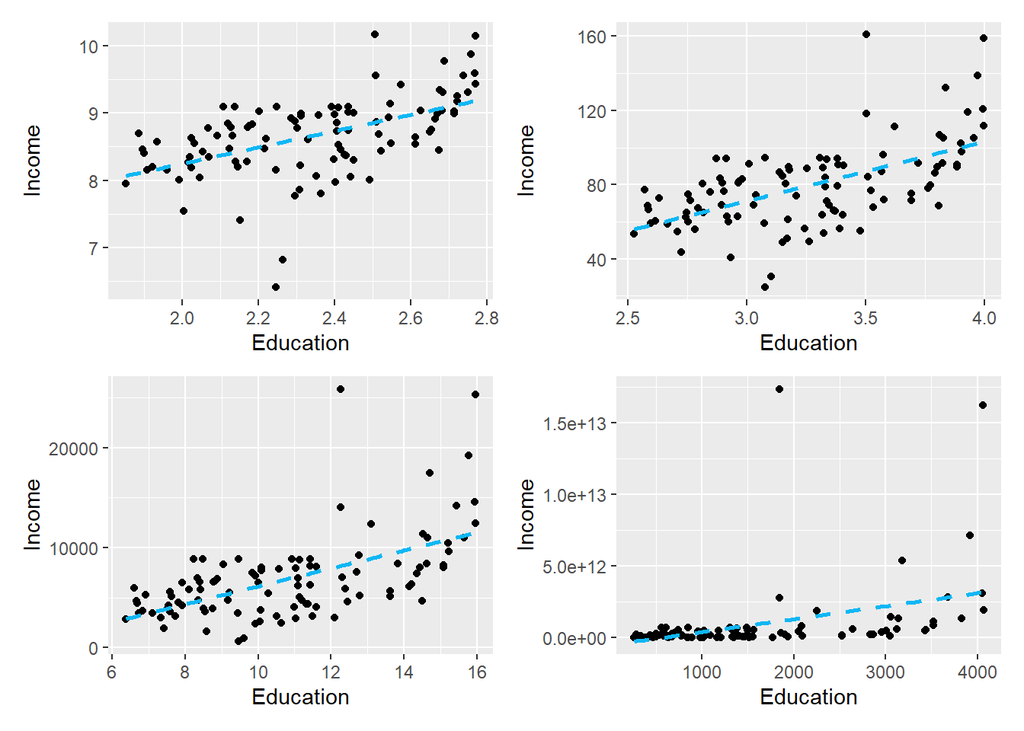

```r
set.seed(5)
sampled_data <- sample(models, size = 4)

plots <- map(sampled_data, ~ {
  ggplot(
    as.data.frame(.x[c("income", "education")]),
    aes(x = education, y = income)
  ) +
    geom_point() +
    geom_smooth(
      method = "lm",
      formula = y ~ x,
      se = FALSE,
      color = "#10b7f4",
      linetype = "dashed"
    ) +
    labs(x = "Education", y = "Income")
})

reduce(plots, `+`)
```

From the list of all the models, the best one can be found by selecting the one who posses the greater r squared

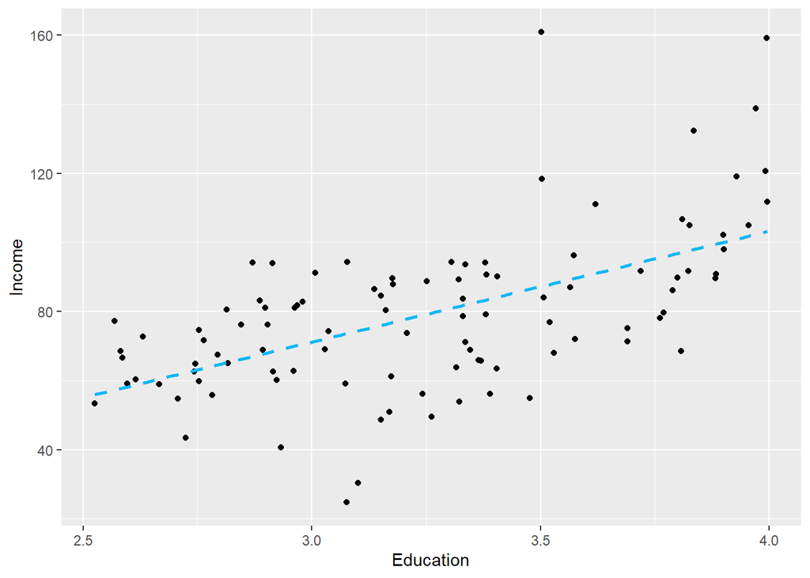

```r
best_model <- models[[which.max(map_dbl(models, "r_squared"))]]

ggplot(
  as.data.frame(best_model[c("income", "education")]),
  aes(x = education, y = income)
) +
  geom_point() +
  geom_smooth(
    method = "lm",
    formula = y ~ x,
    se = FALSE,
    color = "#10b7f4",
    linetype = "dashed"
  ) +
  labs(x = "Education", y = "Income")
```

```r
summary(best_model$model)
```

```
##
## Call:
## lm(formula = income ~ education, data = data)
##
## Residuals:
##     Min      1Q  Median      3Q     Max
## -48.856 -10.978   1.046  10.927  73.623
##
## Coefficients:
##             Estimate Std. Error t value Pr(>|t|)
## (Intercept)  -25.201     14.854  -1.697   0.0929 .
## education     32.115      4.533   7.085 1.99e-10 ***
## ---
## Signif. codes:  0 '***' 0.001 '**' 0.01 '*' 0.05 '.' 0.1 ' ' 1
##
## Residual standard error: 18.89 on 100 degrees of freedom
## Multiple R-squared:  0.3342, Adjusted R-squared:  0.3275
## F-statistic: 50.19 on 1 and 100 DF,  p-value: 1.987e-10
```